# PISA Data Exploration

## Preliminary Wrangling

> PISA is a survey of students' skills and knowledge as they approach the end of compulsory education. It is not a conventional school test. Rather than examining how well students have learned the school curriculum, it looks at how well prepared they are for life beyond school.

```python
# import all packages and set plots to be embedded inline
import numpy as np
import pandas as pd
import matplotlib.pyplot as plt
import seaborn as sb

%matplotlib inline
```

> I will first open the PISA 2012 CSV file and see if I can make sense of it.

```python
df = pd.read_csv('pisa2012.csv', low_memory = False)
df = df.iloc[:, 1:]
df.head()
```

|  | CNT | SUBNATIO | STRATUM | OECD | NC | SCHOOLID | STIDSTD | ST01Q01 | ST02Q01 | ST03Q01 | ... | W_FSTR75 | W_FSTR76 | W_FSTR77 | W_FSTR78 | W_FSTR79 | W_FSTR80 | WVARSTRR | VAR_UNIT | SENWGT_STU | VER_STU |
| --- | --- | --- | --- | --- | --- | --- | --- | --- | --- | --- | --- | --- | --- | --- | --- | --- | --- | --- | --- | --- | --- |
| 0 | Albania | 80000 | ALB0006 | Non-OECD | Albania | 1 | 1 | 10 | 1.0 | 2 | ... | 13.7954 | 13.9235 | 13.1249 | 13.1249 | 4.3389 | 13.0829 | 19 | 1 | 0.2098 | 22NOV13 |
| 1 | Albania | 80000 | ALB0006 | Non-OECD | Albania | 1 | 2 | 10 | 1.0 | 2 | ... | 13.7954 | 13.9235 | 13.1249 | 13.1249 | 4.3389 | 13.0829 | 19 | 1 | 0.2098 | 22NOV13 |
| 2 | Albania | 80000 | ALB0006 | Non-OECD | Albania | 1 | 3 | 9 | 1.0 | 9 | ... | 12.7307 | 12.7307 | 12.7307 | 12.7307 | 4.2436 | 12.7307 | 19 | 1 | 0.1999 | 22NOV13 |
| 3 | Albania | 80000 | ALB0006 | Non-OECD | Albania | 1 | 4 | 9 | 1.0 | 8 | ... | 12.7307 | 12.7307 | 12.7307 | 12.7307 | 4.2436 | 12.7307 | 19 | 1 | 0.1999 | 22NOV13 |
| 4 | Albania | 80000 | ALB0006 | Non-OECD | Albania | 1 | 5 | 9 | 1.0 | 10 | ... | 12.7307 | 12.7307 | 12.7307 | 12.7307 | 4.2436 | 12.7307 | 19 | 1 | 0.1999 | 22NOV13 |

5 rows × 635 columns

```python
df.shape
```

```
(485490, 635)
```

```python
df.info(verbose=True)
```

```
<class 'pandas.core.frame.DataFrame'>
RangeIndex: 485490 entries, 0 to 485489
Data columns (total 635 columns):
 #    Column       Dtype
---   ------       -----
 0    CNT          object
 1    SUBNATIO     int64
 2    STRATUM      object
 3    OECD         object
 4    NC           object
 5    SCHOOLID     int64
 6    STIDSTD      int64
 7    ST01Q01      int64
 8    ST02Q01      float64
 9    ST03Q01      int64
```

[output cut: 627 more lines]

> I will first creat a copy of the dataset and work with it.

```python
df_clean = df.copy()
df_clean.head(2)
```

|  | CNT | SUBNATIO | STRATUM | OECD | NC | SCHOOLID | STIDSTD | ST01Q01 | ST02Q01 | ST03Q01 | ... | W_FSTR75 | W_FSTR76 | W_FSTR77 | W_FSTR78 | W_FSTR79 | W_FSTR80 | WVARSTRR | VAR_UNIT | SENWGT_STU | VER_STU |
| --- | --- | --- | --- | --- | --- | --- | --- | --- | --- | --- | --- | --- | --- | --- | --- | --- | --- | --- | --- | --- | --- |
| 0 | Albania | 80000 | ALB0006 | Non-OECD | Albania | 1 | 1 | 10 | 1.0 | 2 | ... | 13.7954 | 13.9235 | 13.1249 | 13.1249 | 4.3389 | 13.0829 | 19 | 1 | 0.2098 | 22NOV13 |
| 1 | Albania | 80000 | ALB0006 | Non-OECD | Albania | 1 | 2 | 10 | 1.0 | 2 | ... | 13.7954 | 13.9235 | 13.1249 | 13.1249 | 4.3389 | 13.0829 | 19 | 1 | 0.2098 | 22NOV13 |

2 rows × 635 columns

> Since I'm not interested in the 635 columns, I'll drop all except those I'm interested in.

```python
df_clean = df_clean[['CNT', 'ST04Q01', 'ST13Q01', 'ST17Q01', 'ST26Q02',
                     'ST26Q03', 'ST26Q05','ST26Q06', 'ST27Q03', 'AGE',
                     'GRADE', 'ANXMAT', 'LANGN', 'WEALTH', 'PV1MATH',
                     'PV1READ', 'PV1SCIE']]
```

```python
df_clean.columns = ['country', 'gender', 'mother_school', 'father_school', 'has_room',
                    'has_studyplace', 'has_software', 'has_internet', 'hm_computers', 'age',
                    'grade', 'mat_anx', 'language', 'wealth', 'grades_math',
                    'grades_read', 'grades_science']
```

```python
df_clean.head()
```

|  | country | gender | mother_school | father_school | has_room | has_studyplace | has_software | has_internet | hm_computers | age | grade | mat_anx | language | wealth | grades_math | grades_read | grades_science |
| --- | --- | --- | --- | --- | --- | --- | --- | --- | --- | --- | --- | --- | --- | --- | --- | --- | --- |
| 0 | Albania | Female | <ISCED level 3A> | <ISCED level 3A> | No | Yes | No | No | None | 16.17 | 0.0 | 0.32 | Albanian | -2.92 | 406.8469 | 249.5762 | 341.7009 |
| 1 | Albania | Female | <ISCED level 3A> | <ISCED level 3A> | Yes | Yes | Yes | Yes | Three or more | 16.17 | 0.0 | NaN | Albanian | 0.69 | 486.1427 | 406.2936 | 548.9929 |
| 2 | Albania | Female | <ISCED level 3B, 3C> | <ISCED level 3A> | Yes | Yes | No | Yes | Two | 15.58 | -1.0 | NaN | Albanian | -0.23 | 533.2684 | 401.2100 | 499.6643 |
| 3 | Albania | Female | <ISCED level 3B, 3C> | <ISCED level 3A> | Yes | Yes | Yes | Yes | One | 15.67 | -1.0 | 0.31 | Albanian | -1.17 | 412.2215 | 547.3630 | 438.6796 |
| 4 | Albania | Female | She did not complete <ISCED level 1> | <ISCED level 3B, 3C> | Yes | No | Yes | Yes | Two | 15.50 | -1.0 | 1.02 | Albanian | -1.17 | 381.9209 | 311.7707 | 361.5628 |

```python
df_clean.info()
```

```
<class 'pandas.core.frame.DataFrame'>
RangeIndex: 485490 entries, 0 to 485489
Data columns (total 17 columns):
 #   Column          Non-Null Count   Dtype
---  ------          --------------   -----
 0   country         485490 non-null  object
 1   gender          485490 non-null  object
 2   mother_school   457979 non-null  object
 3   father_school   443261 non-null  object
 4   has_room        469693 non-null  object
 5   has_studyplace  472020 non-null  object
 6   has_software    463178 non-null  object
 7   has_internet    473182 non-null  object
 8   hm_computers    473459 non-null  object
 9   age             485374 non-null  float64
 10  grade           484617 non-null  float64
 11  mat_anx         314764 non-null  float64
 12  language        481765 non-null  object
 13  wealth          479597 non-null  float64
 14  grades_math     485490 non-null  float64
 15  grades_read     485490 non-null  float64
 16  grades_science  485490 non-null  float64
dtypes: float64(7), object(10)
memory usage: 63.0+ MB
```

```python
df_clean.shape
```

```
(485490, 17)
```

```python
df_clean.describe()
```

|  | age | grade | mat_anx | wealth | grades_math | grades_read | grades_science |
| --- | --- | --- | --- | --- | --- | --- | --- |
| count | 485374.000000 | 484617.000000 | 314764.000000 | 479597.00000 | 485490.000000 | 485490.000000 | 485490.000000 |
| mean | 15.784283 | -0.162964 | 0.152647 | -0.33701 | 469.621653 | 472.004640 | 475.769824 |
| std | 0.290221 | 0.655558 | 0.955031 | 1.21530 | 103.265391 | 102.505523 | 101.464426 |
| min | 15.170000 | -3.000000 | -2.370000 | -6.65000 | 19.792800 | 0.083400 | 2.648300 |
| 25% | 15.580000 | 0.000000 | -0.470000 | -1.04000 | 395.318600 | 403.600700 | 404.457300 |
| 50% | 15.750000 | 0.000000 | 0.060000 | -0.30000 | 466.201900 | 475.455000 | 475.699400 |
| 75% | 16.000000 | 0.000000 | 0.790000 | 0.43000 | 541.057800 | 544.502500 | 547.780700 |
| max | 16.330000 | 3.000000 | 2.550000 | 3.25000 | 962.229300 | 904.802600 | 903.338300 |

### What is the structure of your dataset?

> The original dataset has 485.490 rows and 635 columns. I will not be using all that data, so I copied it and left in the dataset only the columns I am interested in. The clean dataset has 485.490 rows and 17 columns.

### What is/are the main feature(s) of interest in your dataset?

> - What factors affect a child's grade?
> - What is the relationship between wealth and grades?
> - How does having anxiety about math affect a child's grades?
> - Does the country where the child is affect its development?
> - Are there any differences by gender?
> - Do children whose parends are more educated perform better?
> - Are wealthier children more successful?

### What features in the dataset do you think will help support your investigation into your feature(s) of interest?

> A good way to answering those questions would be by making visualizations with the columns I subsetted, such as `wealth`, `grade`, `gender` and `country`.

## Univariate Exploration

> In this section, investigate distributions of individual variables. If you see unusual points or outliers, take a deeper look to clean things up and prepare yourself to look at relationships between variables.

> First I'll see the distribution of the data. I'll see which are the twenty most common countries in the dataset.

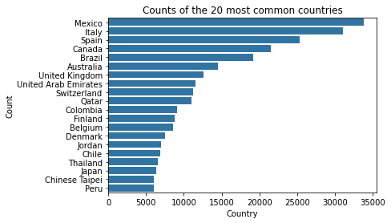

```python
base_color = sb.color_palette()[0]
order = df_clean.country.value_counts().iloc[:20].index
sb.countplot(data = df_clean, y = 'country', order = order,
            color = base_color)
plt.xlabel('Country')
plt.ylabel('Count')
plt.title('Counts of the 20 most common countries');
```

> We can see that the first most common country is Mexico, followed by Italy and Spain in the top three. Now I will see what's the distribution of students with internet.

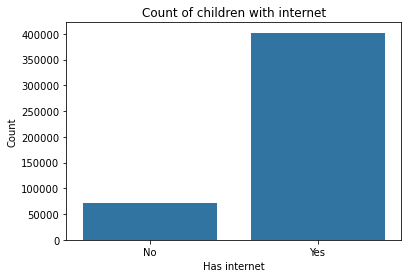

```python
sb.countplot(data = df_clean, x = 'has_internet',
            color = base_color)
plt.xlabel('Has internet')
plt.ylabel('Count')
plt.title('Count of children with internet');
```

> Most of the students have internet, though a relevant portion does not. Later on I will try and see if that seems to affect their grades. With the same idea in mind, I'll see how many computers students tend to have, and whether they have a room and/or a study place.

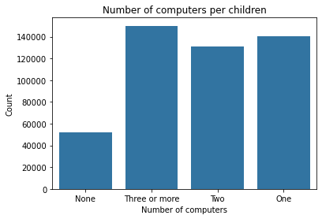

```python
sb.countplot(data = df_clean, x = 'hm_computers',
            color = base_color)
plt.xlabel('Number of computers')
plt.ylabel('Count')
plt.title('Number of computers per children');
```

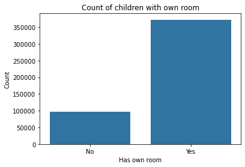

```python
sb.countplot(data = df_clean, x = 'has_room',
            color = base_color)
plt.xlabel('Has own room')
plt.ylabel('Count')
plt.title('Count of children with own room');
```

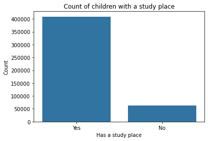

```python
sb.countplot(data = df_clean, x = 'has_studyplace',
            color = base_color)
plt.xlabel('Has a study place')
plt.ylabel('Count')
plt.title('Count of children with a study place');
```

> We can see that most children have at least one computer, but still, a relevant number of children have none. The same happens with children having an own room or a study place. Most of them do, but over 50000 children don't have a study place and almost 100000 children don't have their own room. Now I'm interested in the distribution by gender, by language and by age.

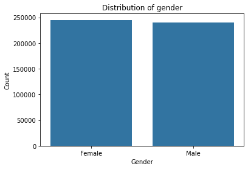

```python
sb.countplot(data = df_clean, x = 'gender',
            color = base_color)
plt.xlabel('Gender')
plt.ylabel('Count')
plt.title('Distribution of gender');
```

> It is well balanced by gender, with almost half female and almost half male.

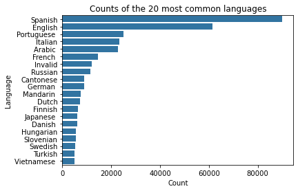

```python
order = df_clean.language.value_counts().iloc[:20].index
sb.countplot(data = df_clean, y = 'language', order = order,
            color = base_color)
plt.xlabel('Count')
plt.ylabel('Language')
plt.title('Counts of the 20 most common languages');
```

> The most spoken language in the PISA exams is Spanish, followed by English by a large difference, and followed by Portuguese also by a large difference.

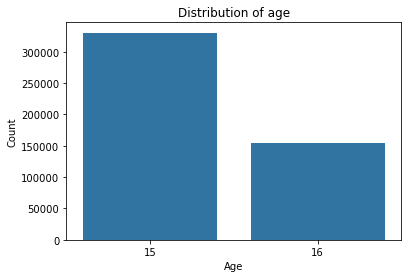

```python
sb.countplot(data = df_clean, x = df_clean.dropna(subset=['age'])['age'].astype(int),
            color = base_color)
plt.xlabel('Age')
plt.ylabel('Count')
plt.title('Distribution of age');
```

> Most of the children are 15, while half as many are 16. I'll see now the distribution of wealth.

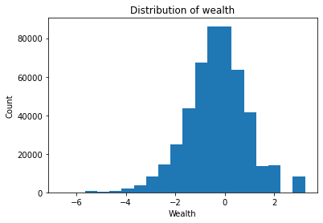

```python
plt.hist(data = df_clean, x = 'wealth', bins = 20)
plt.xlabel('Wealth')
plt.ylabel('Count')
plt.title('Distribution of wealth');
```

> The data is formatted in a way that makes 0 be the averge wealth. It is, therefore, normally distributed. We can see that more children have a wealth below average.

> I'm also interested in the highest schooling achieved by the mother and the father of the children. Later on I'll see how lower parental education correlates with grades, if at all.

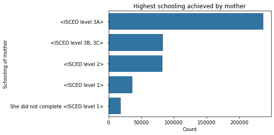

```python
order = df_clean.mother_school.value_counts().index
sb.countplot(data = df_clean, y = 'mother_school', order = order,
            color = base_color)
plt.xlabel('Count')
plt.ylabel('Schooling of mother')
plt.title('Highest schooling achieved by mother');
```

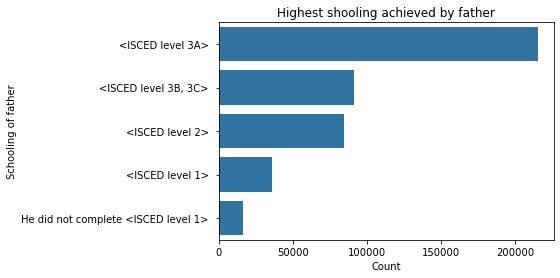

```python
order = df_clean.father_school.value_counts().index
sb.countplot(data = df_clean, y = 'father_school', order = order,
            color = base_color)
plt.xlabel('Count')
plt.ylabel('Schooling of father')
plt.title('Highest shooling achieved by father');
```

> Apparently a lot of parents finished ISCED leven 3A, the highest mentioned in this dataset, but a high number of parents achieved less than that. Now I will see the distribution of grades, to see how children tend to do regardless of any other information.

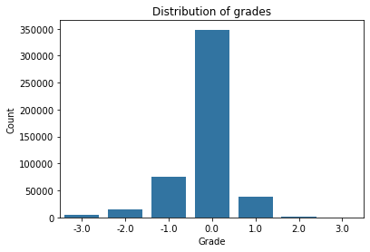

```python
sb.countplot(data = df_clean, x = 'grade', color = base_color)
plt.xlabel('Grade')
plt.ylabel('Count')
plt.title('Distribution of grades');
```

> The data is formatted in a certain way so that 0 is the average grade. We can see that more children have grades below average.

> Somethings that's worth noticing is that a relevant number of children had no computer and no private room, or place to study. It's worth looking into how that affects their grades.

## Bivariate Exploration

> Now I will explore the relationship between school grade and wealth. I want to see if they are related. First I will do a scatterplot with some jitter to try and see the distribution of the data.

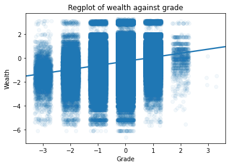

```python
sb.regplot(data = df_clean, x = 'grade', y = 'wealth', truncate = False, x_jitter = 0.3,scatter_kws={'alpha':1/20})
plt.xlabel('Grade')
plt.ylabel('Wealth')
plt.title('Regplot of wealth against grade');
```

> The distribution is not very clear because there are a lot of data points, but we can still get some insights. The most common school grade is the average grade, as expected. There is also a clear trend upwards, which means there is a positive correlation between wealth and grade (as one goes up, the other one goes up as well). This implies that welthier children go to schools where the grade is higher.

> Maybe a violin plot will show us a clearer representation of how the data is distributed.

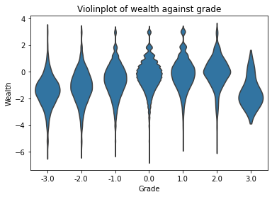

```python
sb.violinplot(data = df_clean, x = 'grade', y = 'wealth', color = base_color, inner = None)
plt.xlabel('Grade')
plt.ylabel('Wealth')
plt.title('Violinplot of wealth against grade');
```

> We can see that the bulk of the data in each grade goes up in wealth as the grade goes up. That is, except on the highest grade. There the bulk on the data is lower than expected. That could be due to there being less data points there (less schools are so demanding, so that data is not as representative as it could be).

> I will now make a boxplot of the same columns to see if/ where there are outliers and where are the medians of the grades.

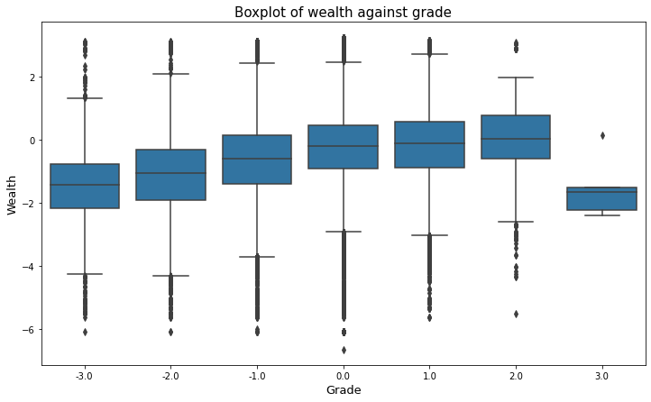

```python
plt.figure(figsize = (12,7))
sb.boxplot(data = df_clean, x = 'grade', y = 'wealth', color = base_color)
plt.xlabel('Grade', fontsize = 13)
plt.ylabel('Wealth', fontsize = 13)
plt.xticks(fontsize = 10)
plt.yticks(fontsize = 10)
plt.title('Boxplot of wealth against grade', fontsize = 15);
```

> We can see that there are a lot of outliers, and we can arrive to the same conclusions we arrived with the violin plot. There is a clear upwards trend, with the medians as well, and the highest grade goes down abruptly in what regards to wealth.

> I will now make some comparisons with the exams grades and wealth.

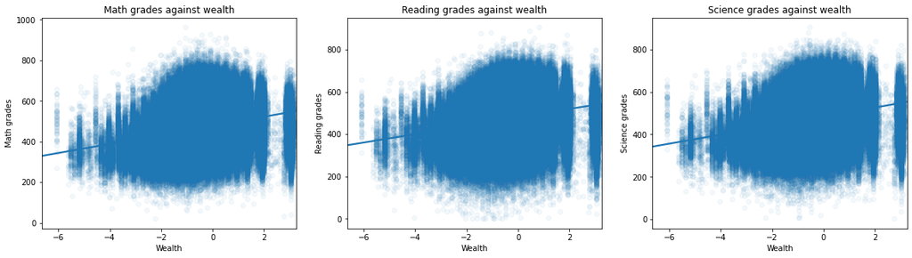

```python
plt.figure(figsize = (20, 5))

plt.subplot(1, 3, 1)
sb.regplot(data = df_clean, x = 'wealth', y = 'grades_math', scatter_kws = {'alpha' : 1/20})
plt.ylabel('Math grades')
plt.xlabel('Wealth')
plt.title('Math grades against wealth');


plt.subplot(1, 3, 2)
sb.regplot(data = df_clean, x = 'wealth', y = 'grades_read', scatter_kws = {'alpha' : 1/20})
plt.ylabel('Reading grades')
plt.xlabel('Wealth')
plt.title('Reading grades against wealth');

plt.subplot(1, 3, 3)
sb.regplot(data = df_clean, x = 'wealth', y = 'grades_science', scatter_kws = {'alpha' : 1/20})
plt.ylabel('Science grades')
plt.xlabel('Wealth')
plt.title('Science grades against wealth');
```

> The scatterplots don't tell us much because there are a lot of points. Still, we can see an upwards trend. Those that are wealthier tend to have better grades. I will do heat maps to see if we can make sense of what the distributions are.

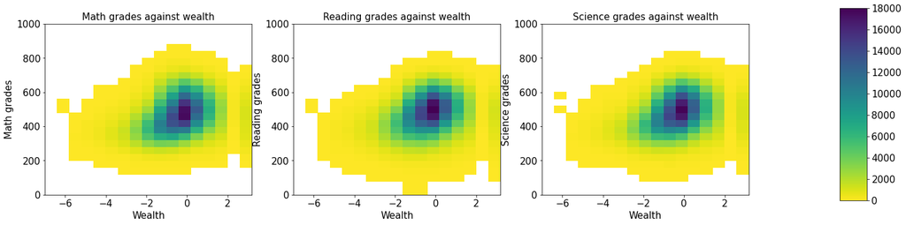

```python
fig, ax = plt.subplots(1, 3, figsize = (20, 5))
bins_x = np.arange(-7, 3+0.6, 0.6)
bins_y = np.arange(0, 1000+40, 40)

plt.subplot(1, 3, 1)
plt.hist2d(data = df_clean[['wealth', 'grades_math']].dropna() , x = 'wealth',
           y = 'grades_math', cmap = 'viridis_r', cmin = 10,
           bins = [bins_x, bins_y], vmin = 0, vmax = 18000)
plt.ylabel('Math grades', fontsize = 15)
plt.xlabel('Wealth', fontsize = 15)
plt.title('Math grades against wealth', fontsize = 15)
plt.xticks(fontsize = 15)
plt.yticks(fontsize = 15)

plt.subplot(1, 3, 2)
plt.hist2d(data = df_clean[['wealth', 'grades_read']].dropna() , x = 'wealth',
           y = 'grades_read', cmap = 'viridis_r', cmin = 10,
           bins = [bins_x, bins_y], vmin = 0, vmax = 18000)
plt.ylabel('Reading grades', fontsize = 15)
plt.xlabel('Wealth', fontsize = 15)
plt.title('Reading grades against wealth', fontsize = 15)
plt.xticks(fontsize = 15)
plt.yticks(fontsize = 15)

plt.subplot(1, 3, 3)
plt.hist2d(data = df_clean[['wealth', 'grades_science']].dropna() ,
           x = 'wealth', y = 'grades_science', cmap = 'viridis_r',
           cmin = 10, bins = [bins_x, bins_y], vmin = 0, vmax = 18000)
plt.ylabel('Science grades', fontsize = 15)
plt.xlabel('Wealth', fontsize = 15)
plt.title('Science grades against wealth', fontsize = 15)
plt.xticks(fontsize = 15)
plt.yticks(fontsize = 15)

im = plt.gca().get_children()[0]
cax = fig.add_axes([1, 0.1, 0.03, 0.85])
cbar = fig.colorbar(im, cax = cax)
cbar.ax.tick_params(labelsize=15);
```

> We can see that the three exams grades have very similar distributions. Most of the data is in the average wealth (0) and between 400 and 600 in grades.

> Now I will see if there is a relationship between language and grades.

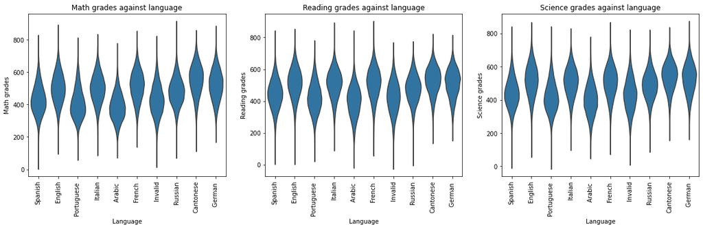

```python
order = df_clean.language.value_counts().iloc[:10].index
plt.figure(figsize = (20, 5))

plt.subplot(1, 3, 1)
sb.violinplot(data = df_clean, x = 'language', y = 'grades_math', order = order, color = base_color, inner = None)
plt.ylabel('Math grades')
plt.xlabel('Language')
plt.title('Math grades against language')
plt.xticks(rotation=90);


plt.subplot(1, 3, 2)
sb.violinplot(data = df_clean, x = 'language', y = 'grades_read', order = order, color = base_color, inner = None)
plt.ylabel('Reading grades')
plt.xlabel('Language')
plt.title('Reading grades against language')
plt.xticks(rotation=90);

plt.subplot(1, 3, 3)
sb.violinplot(data = df_clean, x = 'language', y = 'grades_science', order = order, color = base_color, inner = None)
plt.ylabel('Science grades')
plt.xlabel('Language')
plt.title('Science grades against language')
plt.xticks(rotation=90);
```

> The grades seem to vary slightly with every language but I see no difference that seems relevant.

> Now I will make regplots of the different grades against mathematical anxiety to see if there is some trend.

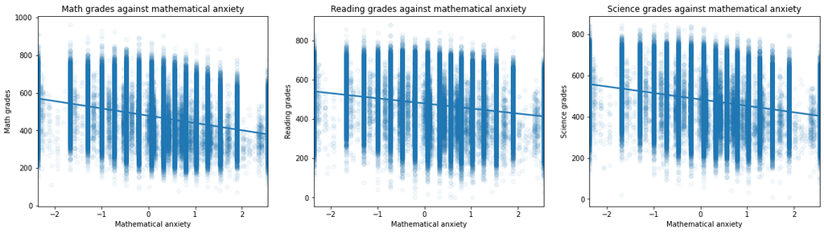

```python
plt.figure(figsize = (20, 5))

plt.subplot(1, 3, 1)
sb.regplot(data = df_clean, x = 'mat_anx', y = 'grades_math', scatter_kws = {'alpha' : 1/20})
plt.ylabel('Math grades')
plt.xlabel('Mathematical anxiety')
plt.title('Math grades against mathematical anxiety');


plt.subplot(1, 3, 2)
sb.regplot(data = df_clean, x = 'mat_anx', y = 'grades_read', scatter_kws = {'alpha' : 1/20})
plt.ylabel('Reading grades')
plt.xlabel('Mathematical anxiety')
plt.title('Reading grades against mathematical anxiety');

plt.subplot(1, 3, 3)
sb.regplot(data = df_clean, x = 'mat_anx', y = 'grades_science', scatter_kws = {'alpha' : 1/20})
plt.ylabel('Science grades')
plt.xlabel('Mathematical anxiety')
plt.title('Science grades against mathematical anxiety');
```

> They are very difficult to interpret but we can see a trend downwards. That means that as mathematican anxiety increases, the grades go down. This could indicate that anxiety makes children perform worse, or that they get anxious after performing poorly, or something else.

> Now I will make heat maps of the different grades against mathematical anxiety to see the distribution.

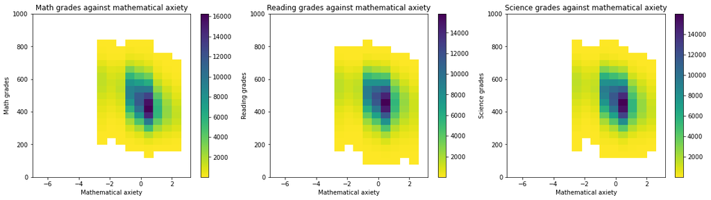

```python
plt.figure(figsize = (20, 5))
bins_x = np.arange(-7, 3+0.6, 0.6)
bins_y = np.arange(0, 1000+40, 40)

plt.subplot(1, 3, 1)
plt.hist2d(data = df_clean[['mat_anx', 'grades_math']].dropna() , x = 'mat_anx',
           y = 'grades_math', cmap = 'viridis_r', cmin = 10, bins = [bins_x, bins_y])
plt.colorbar()
plt.ylabel('Math grades')
plt.xlabel('Mathematical axiety')
plt.title('Math grades against mathematical axiety');

plt.subplot(1, 3, 2)
plt.hist2d(data = df_clean[['mat_anx', 'grades_read']].dropna() , x = 'mat_anx',
           y = 'grades_read', cmap = 'viridis_r', cmin = 10, bins = [bins_x, bins_y])
plt.colorbar()
plt.ylabel('Reading grades')
plt.xlabel('Mathematical axiety')
plt.title('Reading grades against mathematical axiety');

plt.subplot(1, 3, 3)
plt.hist2d(data = df_clean[['mat_anx', 'grades_science']].dropna() , x = 'mat_anx',
           y = 'grades_science', cmap = 'viridis_r', cmin = 10, bins = [bins_x, bins_y])
plt.colorbar()
plt.ylabel('Science grades')
plt.xlabel('Mathematical axiety')
plt.title('Science grades against mathematical axiety');
```

> We can see that most children have grades between around 300 and 500, in all subjets, and have an average anxiety.

> Now I will see if there is a relationship between the schooling of the mother and the grades, and the schooling of the father and the grades.

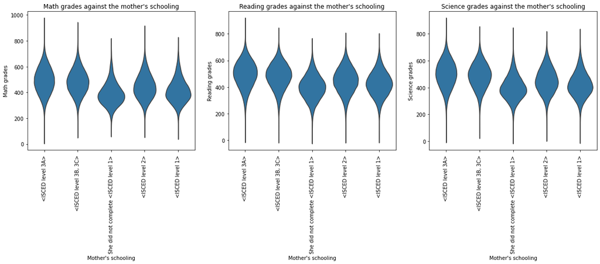

```python
plt.figure(figsize = (20, 5))

plt.subplot(1, 3, 1)
sb.violinplot(data = df_clean, x = 'mother_school', y = 'grades_math', color = base_color, inner = None)
plt.ylabel('Math grades')
plt.xlabel("Mother's schooling")
plt.title("Math grades against the mother's schooling")
plt.xticks(rotation=90);


plt.subplot(1, 3, 2)
sb.violinplot(data = df_clean, x = 'mother_school', y = 'grades_read', color = base_color, inner = None)
plt.ylabel('Reading grades')
plt.xlabel("Mother's schooling")
plt.title("Reading grades against the mother's schooling")
plt.xticks(rotation=90);

plt.subplot(1, 3, 3)
sb.violinplot(data = df_clean, x = 'mother_school', y = 'grades_science', color = base_color, inner = None)
plt.ylabel('Science grades')
plt.xlabel("Mother's schooling")
plt.title("Science grades against the mother's schooling")
plt.xticks(rotation=90);
```

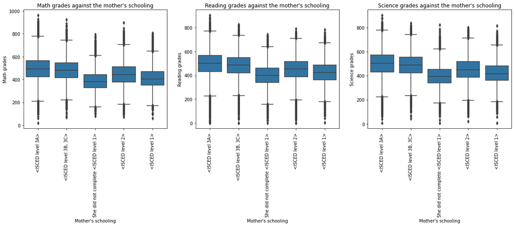

```python
plt.figure(figsize = (20, 5))

plt.subplot(1, 3, 1)
sb.boxplot(data = df_clean, x = 'mother_school', y = 'grades_math', color = base_color)
plt.ylabel('Math grades')
plt.xlabel("Mother's schooling")
plt.title("Math grades against the mother's schooling")
plt.xticks(rotation=90);


plt.subplot(1, 3, 2)
sb.boxplot(data = df_clean, x = 'mother_school', y = 'grades_read', color = base_color)
plt.ylabel('Reading grades')
plt.xlabel("Mother's schooling")
plt.title("Reading grades against the mother's schooling")
plt.xticks(rotation=90);

plt.subplot(1, 3, 3)
sb.boxplot(data = df_clean, x = 'mother_school', y = 'grades_science', color = base_color)
plt.ylabel('Science grades')
plt.xlabel("Mother's schooling")
plt.title("Science grades against the mother's schooling")
plt.xticks(rotation=90);
```

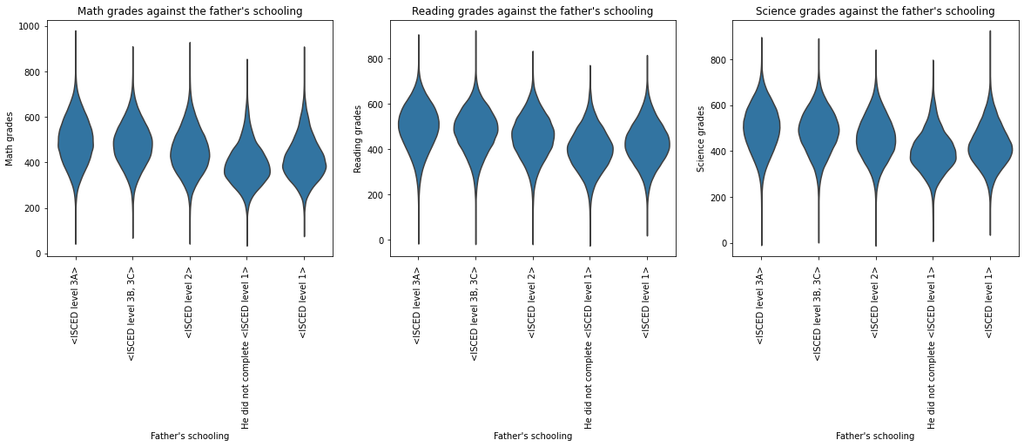

```python
plt.figure(figsize = (20, 5))

plt.subplot(1, 3, 1)
sb.violinplot(data = df_clean, x = 'father_school', y = 'grades_math', color = base_color, inner = None)
plt.ylabel('Math grades')
plt.xlabel("Father's schooling")
plt.title("Math grades against the father's schooling")
plt.xticks(rotation=90);


plt.subplot(1, 3, 2)
sb.violinplot(data = df_clean, x = 'father_school', y = 'grades_read', color = base_color, inner = None)
plt.ylabel('Reading grades')
plt.xlabel("Father's schooling")
plt.title("Reading grades against the father's schooling")
plt.xticks(rotation=90);

plt.subplot(1, 3, 3)
sb.violinplot(data = df_clean, x = 'father_school', y = 'grades_science', color = base_color, inner = None)
plt.ylabel('Science grades')
plt.xlabel("Father's schooling")
plt.title("Science grades against the father's schooling")
plt.xticks(rotation=90);
```

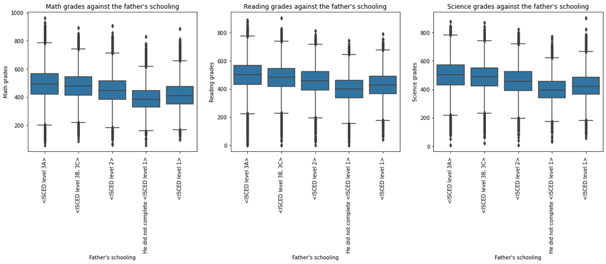

```python
plt.figure(figsize = (20, 5))

plt.subplot(1, 3, 1)
sb.boxplot(data = df_clean, x = 'father_school', y = 'grades_math', color = base_color)
plt.ylabel('Math grades')
plt.xlabel("Father's schooling")
plt.title("Math grades against the father's schooling")
plt.xticks(rotation=90);


plt.subplot(1, 3, 2)
sb.boxplot(data = df_clean, x = 'father_school', y = 'grades_read', color = base_color)
plt.ylabel('Reading grades')
plt.xlabel("Father's schooling")
plt.title("Reading grades against the father's schooling")
plt.xticks(rotation=90);

plt.subplot(1, 3, 3)
sb.boxplot(data = df_clean, x = 'father_school', y = 'grades_science', color = base_color)
plt.ylabel('Science grades')
plt.xlabel("Father's schooling")
plt.title("Science grades against the father's schooling")
plt.xticks(rotation=90);
```

> We can see a clear trend. The less the parents studied, the children performed worst. They are clearly positevely correlated. As one decreased, the other one decreases as well.

### Talk about some of the relationships you observed in this part of the investigation. How did the feature(s) of interest vary with other features in the dataset?

> The main relationships are as follows:
> - There is a positive correlation between wealth and school grade. The wealthier children tend to be in the highest school grades (at the same age).
> - There is a positive correlation between wealth and Math, Science and Reading grades. The wealthier children tend to do better.
> - There didn't seem to be a relevant relationship between language and Math, Science and Reading grades.
> - Math, Science and Reading grades and mathematical anxiety seem to be negatively correlated. As mathematical anxiety increases, grades tend to decrease.
> - Parent's schooling and children Math, Science and Reading grades seem to be positevely correlated. The more the parents studied, the better the children perform.

## Multivariate Exploration

> Create plots of three or more variables to investigate your data even further. Make sure that your investigations are justified, and follow from your work in the previous sections.

> First I will plot the relationship between Math, Science and Reading grades, father's schooling and gender.

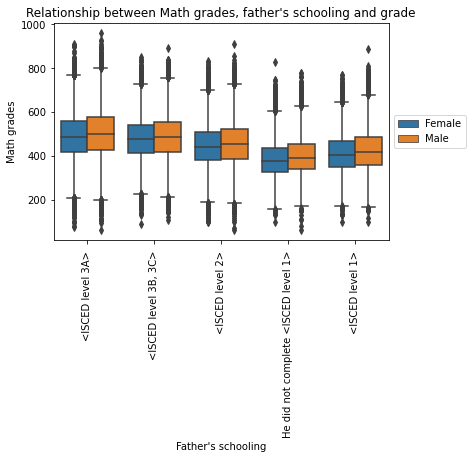

```python
sb.boxplot(data = df_clean, x = 'father_school', y = 'grades_math', hue = 'gender')
plt.legend(loc = 6, bbox_to_anchor = (1.0, 0.5))
plt.xticks(rotation = 90)
plt.title("Relationship between Math grades, father's schooling and grade")
plt.ylabel('Math grades')
plt.xlabel("Father's schooling");
```

> We can see that men tend to be better at math no matter the schooling of the father.

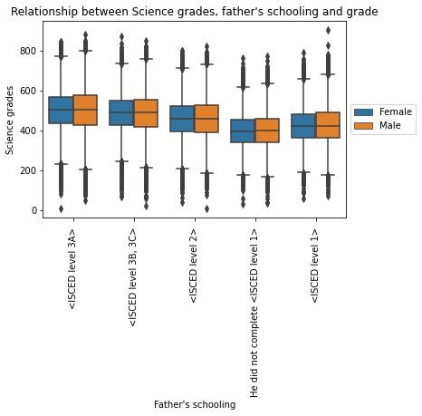

```python
sb.boxplot(data = df_clean, x = 'father_school', y = 'grades_science', hue = 'gender')
plt.legend(loc = 6, bbox_to_anchor = (1.0, 0.5))
plt.xticks(rotation = 90)
plt.title("Relationship between Science grades, father's schooling and grade")
plt.ylabel('Science grades')
plt.xlabel("Father's schooling");
```

> We can see that women and men tend to be pretty similar at science no matter the schooling of the father.

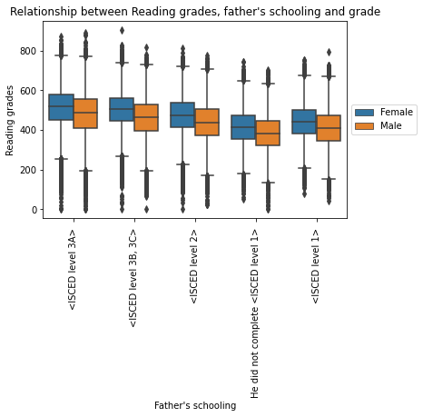

```python
sb.boxplot(data = df_clean, x = 'father_school', y = 'grades_read', hue = 'gender')
plt.legend(loc = 6, bbox_to_anchor = (1.0, 0.5))
plt.xticks(rotation = 90)
plt.title("Relationship between Reading grades, father's schooling and grade")
plt.ylabel('Reading grades')
plt.xlabel("Father's schooling");
```

> We can see that women tend to be better at reading no matter the schooling of the father.

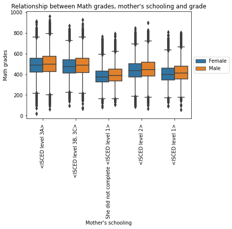

```python
sb.boxplot(data = df_clean, x = 'mother_school', y = 'grades_math', hue = 'gender')
plt.legend(loc = 6, bbox_to_anchor = (1.0, 0.5))
plt.xticks(rotation = 90)
plt.title("Relationship between Math grades, mother's schooling and grade")
plt.ylabel('Math grades')
plt.xlabel("Mother's schooling");
```

> We can see that men tend to be better at math no matter the schooling of the mother.

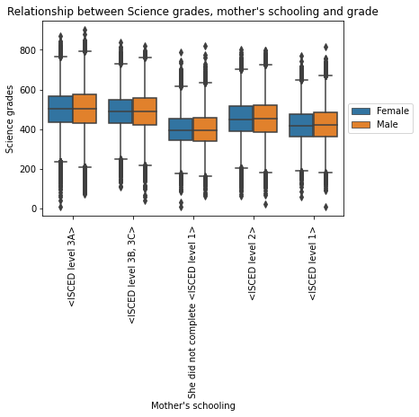

```python
sb.boxplot(data = df_clean, x = 'mother_school', y = 'grades_science', hue = 'gender')
plt.legend(loc = 6, bbox_to_anchor = (1.0, 0.5))
plt.xticks(rotation = 90)
plt.title("Relationship between Science grades, mother's schooling and grade")
plt.ylabel('Science grades')
plt.xlabel("Mother's schooling");
```

> We can see that women and men tend to be pretty similar at science no matter the schooling of the mother.

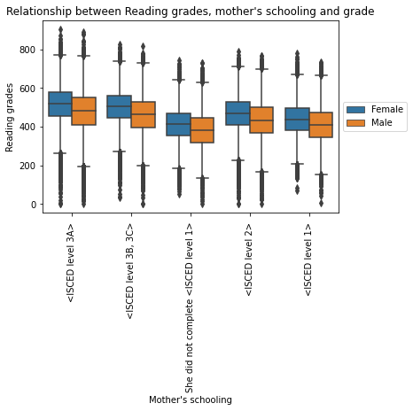

```python
sb.boxplot(data = df_clean, x = 'mother_school', y = 'grades_read', hue = 'gender')
plt.legend(loc = 6, bbox_to_anchor = (1.0, 0.5))
plt.xticks(rotation = 90)
plt.title("Relationship between Reading grades, mother's schooling and grade")
plt.ylabel('Reading grades')
plt.xlabel("Mother's schooling");
```

> We can see that women tend to be better at reading no matter the schooling of the mother.

> Now I will make a pairplot of the Math, Reading and Science grades.

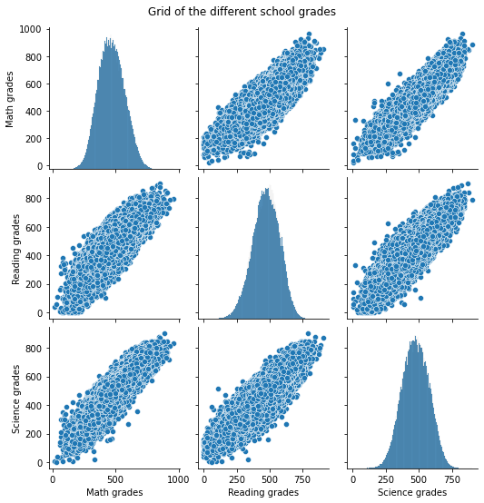

```python
# to have appropriate axis names I will rename the columns that I will use and save it in a copied dataframe

df_clean2 = df_clean.rename(columns={'grades_math': 'Math grades', 'grades_read': 'Reading grades',
                                     'grades_science': 'Science grades'})

g = sb.pairplot(data = df_clean2, vars = ['Math grades', 'Reading grades', 'Science grades'])
g.fig.suptitle("Grid of the different school grades", y = 1.02);
```

> We can see that all the different grades are positevely correlated. Children that do well on one subject tend to also do well on the others.

### Relationships

> In this part I observed the following relationships:
> - Men tend to be better at Math grades than women no matter the schooling of the father or the mother.
> - Women and men tend have similar grades at Science no matter the schooling of the father or the mother.
> - Women tend to be better at Reading no matter the schooling of the father or the mother.
> - Math, Reading and Science grades are all positively correlated with eachother.